# Business Problem

Financial institutions face significant losses when borrowers fail to repay their loans. Identifying factors associated with loan default can help lenders improve risk assessment, reduce financial losses, and make better lending decisions.

The objective of this analysis is to explore borrower characteristics, loan attributes, and repayment behaviour to identify patterns associated with loan default risk.

```python
# Import data analysis libraries
import pandas as pd
import numpy as np

# Import visualisation libraries
import matplotlib.pyplot as plt
import seaborn as sns
```

```python
# Load dataset from data folder
df = pd.read_csv("../data/raw/loan_default_dataset_noisy.csv")

# Preview first 5 rows
df.head()
```

|  | CustomerID | Age | Gender | Marital_Status | Education | Employment_Type | ApplicantIncome | CoapplicantIncome | LoanAmount | Loan_Amount_Term | Credit_History | Property_Area | Income_Loan_Ratio | Loan_Status |
| --- | --- | --- | --- | --- | --- | --- | --- | --- | --- | --- | --- | --- | --- | --- |
| 0 | 1000 | 59 | Male | Single | Not Graduate | Salaried | 11082 | 3363 | 284.0 | 120 | 1.0 | Semiurban | 0.508627 | Y |
| 1 | 1001 | 49 | NaN | Married | Graduate | Salaried | 10822 | 3524 | 164.0 | 360 | 0.0 | Semiurban | 0.874756 | Y |
| 2 | 1002 | 35 | Male | Married | Graduate | Salaried | 3986 | 3786 | 414.0 | 240 | 1.0 | Semiurban | 0.187729 | N |
| 3 | 1003 | 63 | Male | Single | Not Graduate | Salaried | 10526 | 23 | 139.0 | 300 | 1.0 | Rural | 0.758921 | Y |
| 4 | 1004 | 28 | Female | Married | Graduate | Salaried | 9918 | 3003 | 257.0 | 240 | 0.0 | Urban | 0.502763 | N |

# Dataset Overview

The dataset contains borrower demographic information, financial indicators, loan characteristics, and repayment outcomes.

Key variables include:

- Applicant Income
- Coapplicant Income
- Loan Amount
- Loan Term
- Credit History
- Education
- Employment Status
- Property Area
- Loan Status

The dataset will be cleaned, transformed, and analysed to identify key drivers of loan default risk.

```python
# Check data types and missing values
df.info()
```

```
<class 'pandas.DataFrame'>
RangeIndex: 2100 entries, 0 to 2099
Data columns (total 14 columns):
 #   Column             Non-Null Count  Dtype
---  ------             --------------  -----
 0   CustomerID         2100 non-null   int64
 1   Age                2100 non-null   int64
 2   Gender             1995 non-null   str
 3   Marital_Status     1993 non-null   str
 4   Education          2100 non-null   str
 5   Employment_Type    2100 non-null   str
 6   ApplicantIncome    2100 non-null   int64
 7   CoapplicantIncome  2100 non-null   int64
 8   LoanAmount         1994 non-null   float64
 9   Loan_Amount_Term   2100 non-null   int64
 10  Credit_History     1993 non-null   float64
 11  Property_Area      2100 non-null   str
 12  Income_Loan_Ratio  2100 non-null   float64
 13  Loan_Status        2100 non-null   str
dtypes: float64(3), int64(5), str(6)
memory usage: 229.8 KB
```

```python
# Summary statistics for numerical columns
df.describe()
```

|  | CustomerID | Age | ApplicantIncome | CoapplicantIncome | LoanAmount | Loan_Amount_Term | Credit_History | Income_Loan_Ratio |
| --- | --- | --- | --- | --- | --- | --- | --- | --- |
| count | 2100.000000 | 2100.000000 | 2100.000000 | 2100.000000 | 1994.000000 | 2100.000000 | 1993.000000 | 2100.000000 |
| mean | 2001.513810 | 42.670000 | 8290.765238 | 4049.764762 | 270.344534 | 240.571429 | 0.792775 | 0.640285 |
| std | 578.359094 | 12.603574 | 3912.710716 | 2288.544407 | 128.411200 | 85.535374 | 0.405420 | 0.547168 |
| min | 1000.000000 | 21.000000 | 1512.000000 | 2.000000 | 50.000000 | 120.000000 | 0.000000 | 0.047368 |
| 25% | 1499.750000 | 32.000000 | 4910.750000 | 2067.250000 | 158.250000 | 180.000000 | 1.000000 | 0.297800 |
| 50% | 2002.500000 | 43.000000 | 8367.500000 | 4050.500000 | 271.000000 | 240.000000 | 1.000000 | 0.457574 |
| 75% | 2503.250000 | 54.000000 | 11666.000000 | 6001.250000 | 379.000000 | 300.000000 | 1.000000 | 0.772765 |
| max | 2999.000000 | 64.000000 | 14999.000000 | 7999.000000 | 499.000000 | 360.000000 | 1.000000 | 4.034510 |

```python
# Count missing values per column
df.isnull().sum()
```

```
CustomerID             0
Age                    0
Gender               105
Marital_Status       107
Education              0
Employment_Type        0
ApplicantIncome        0
CoapplicantIncome      0
LoanAmount           106
Loan_Amount_Term       0
Credit_History       107
Property_Area          0
Income_Loan_Ratio      0
Loan_Status            0
dtype: int64
```

```python
# Count duplicate rows
df.duplicated().sum()
```

```
np.int64(100)
```

```python
# Remove duplicate rows
df = df.drop_duplicates()
```

```python
# Fill numerical missing values with median
df["LoanAmount"] = df["LoanAmount"].fillna(df["LoanAmount"].median())

# Fill categorical missing values with mode
df["Gender"] = df["Gender"].fillna(df["Gender"].mode()[0])
df["Marital_Status"] = df["Marital_Status"].fillna(df["Marital_Status"].mode()[0])
df["Credit_History"] = df["Credit_History"].fillna(df["Credit_History"].mode()[0])
```

```python
# Fix column names (remove spaces)
df.columns = df.columns.str.strip()

# Identify text columns
text_columns = df.select_dtypes(include=["object", "string"]).columns

# Standardise text (lowercase + remove spaces)
for col in text_columns:
    df[col] = df[col].apply(lambda x: x.strip().lower() if isinstance(x, str) else x)

# Convert selected columns to title case for readability
cols_to_title = ["Gender", "Marital_Status", "Education", "Employment_Type", "Property_Area"]

for col in cols_to_title:
    if col in df.columns:
        df[col] = df[col].apply(lambda x: x.title() if isinstance(x, str) else x)
```

```python
# Check values before mapping
print(df["Loan_Status"].unique())
# Convert to numeric (after cleaning → values are lowercase)
df["Loan_Status"] = df["Loan_Status"].map({"y": 1, "n": 0})

# Verify conversion
df["Loan_Status"].value_counts()
```

```
<StringArray>
['y', 'n']
Length: 2, dtype: str
```

```
Loan_Status
1    1040
0     960
Name: count, dtype: int64
```

```python
# Create total income
df["Total_Income"] = df["ApplicantIncome"] + df["CoapplicantIncome"]

# Create loan-to-income ratio
df["Loan_Income_Ratio"] = df["LoanAmount"] / df["Total_Income"]
```

# Data Cleaning Summary

Several data quality checks and cleaning procedures were performed to improve dataset reliability:

- Missing values identified and handled
- Duplicate records detected and removed
- Data types validated
- Text values standardized
- Loan status converted to numeric format
- New analytical features created
- Dataset validated after cleaning

These steps ensure the analysis is based on accurate and consistent data.

```python
# Preview cleaned dataset
df.head()
```

|  | CustomerID | Age | Gender | Marital_Status | Education | Employment_Type | ApplicantIncome | CoapplicantIncome | LoanAmount | Loan_Amount_Term | Credit_History | Property_Area | Income_Loan_Ratio | Loan_Status | Total_Income | Loan_Income_Ratio |
| --- | --- | --- | --- | --- | --- | --- | --- | --- | --- | --- | --- | --- | --- | --- | --- | --- |
| 0 | 1000 | 59 | Male | Single | Not Graduate | Salaried | 11082 | 3363 | 284.0 | 120 | 1.0 | Semiurban | 0.508627 | 1 | 14445 | 0.019661 |
| 1 | 1001 | 49 | Female | Married | Graduate | Salaried | 10822 | 3524 | 164.0 | 360 | 0.0 | Semiurban | 0.874756 | 1 | 14346 | 0.011432 |
| 2 | 1002 | 35 | Male | Married | Graduate | Salaried | 3986 | 3786 | 414.0 | 240 | 1.0 | Semiurban | 0.187729 | 0 | 7772 | 0.053268 |
| 3 | 1003 | 63 | Male | Single | Not Graduate | Salaried | 10526 | 23 | 139.0 | 300 | 1.0 | Rural | 0.758921 | 1 | 10549 | 0.013177 |
| 4 | 1004 | 28 | Female | Married | Graduate | Salaried | 9918 | 3003 | 257.0 | 240 | 0.0 | Urban | 0.502763 | 0 | 12921 | 0.019890 |

```python
# Final check of cleaned data
df.info()
```

```
<class 'pandas.DataFrame'>
RangeIndex: 2000 entries, 0 to 1999
Data columns (total 16 columns):
 #   Column             Non-Null Count  Dtype
---  ------             --------------  -----
 0   CustomerID         2000 non-null   int64
 1   Age                2000 non-null   int64
 2   Gender             2000 non-null   str
 3   Marital_Status     2000 non-null   str
 4   Education          2000 non-null   str
 5   Employment_Type    2000 non-null   str
 6   ApplicantIncome    2000 non-null   int64
 7   CoapplicantIncome  2000 non-null   int64
 8   LoanAmount         2000 non-null   float64
 9   Loan_Amount_Term   2000 non-null   int64
 10  Credit_History     2000 non-null   float64
 11  Property_Area      2000 non-null   str
 12  Income_Loan_Ratio  2000 non-null   float64
 13  Loan_Status        2000 non-null   int64
 14  Total_Income       2000 non-null   int64
 15  Loan_Income_Ratio  2000 non-null   float64
dtypes: float64(4), int64(7), str(5)
memory usage: 250.1 KB
```

```python
# Save cleaned dataset to new CSV file
df.to_csv("../data/cleaned/loan_default_dataset_cleaned.csv", index=False)
```

# Exploratory Data Analysis

Exploratory analysis was conducted to understand borrower characteristics, loan distributions, repayment behaviour, and relationships between variables.

The visualizations below highlight important patterns that may influence loan default risk.

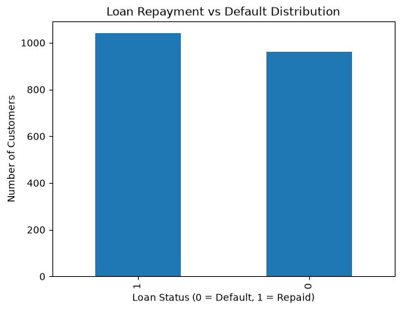

```python
# Loan Default Distribution
df["Loan_Status"].value_counts().plot(kind="bar")

plt.title("Loan Repayment vs Default Distribution")
plt.xlabel("Loan Status (0 = Default, 1 = Repaid)")
plt.ylabel("Number of Customers")

# plt.savefig("../images/09_default_distribution.png")
plt.show()
```

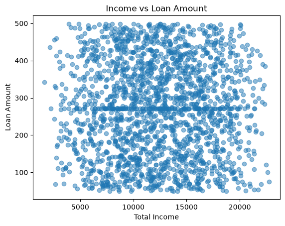

```python
# Income vs Loan Amount
plt.scatter(df["Total_Income"], df["LoanAmount"], alpha=0.5)

plt.title("Income vs Loan Amount")
plt.xlabel("Total Income")
plt.ylabel("Loan Amount")

#plt.savefig("../images/10_income_vs_loan.png")
plt.show()
```

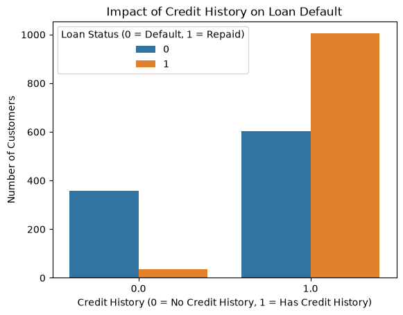

```python
# Credit History vs Default
sns.countplot(x="Credit_History", hue="Loan_Status", data=df)

plt.title("Impact of Credit History on Loan Default")
plt.xlabel("Credit History (0 = No Credit History, 1 = Has Credit History)")
plt.ylabel("Number of Customers")

plt.legend(title="Loan Status (0 = Default, 1 = Repaid)")

# plt.savefig("../images/11_credit_vs_default.png")
plt.show()
```

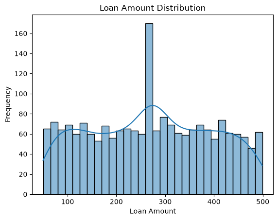

```python
# Loan Amount Distribution (Seaborn)
sns.histplot(df["LoanAmount"], bins=30, kde=True)

plt.title("Loan Amount Distribution")
plt.xlabel("Loan Amount")
plt.ylabel("Frequency")

#plt.fig("../images/12_loan_distribution.png")
plt.show()
```

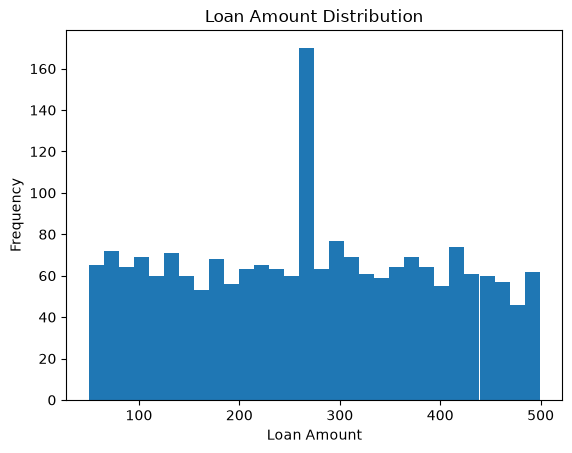

```python
# Using Matplotlib only for Chart 4 (without KDE)

# Chart 4 — Loan Amount Distribution (Matplotlib only)
plt.hist(df["LoanAmount"], bins=30)

plt.title("Loan Amount Distribution")
plt.xlabel("Loan Amount")
plt.ylabel("Frequency")

# plt.savefig("../images/12_loan_distribution.png")
plt.show()
```

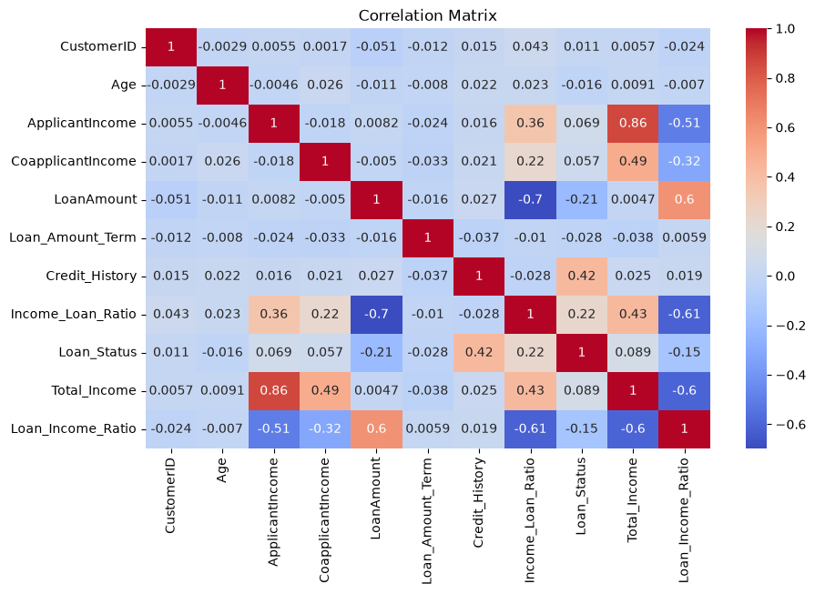

```python
# Correlation Matrix
plt.figure(figsize=(10,6))

sns.heatmap(df.corr(numeric_only=True), annot=True, cmap="coolwarm")

plt.title("Correlation Matrix")

# plt.savefig("../images/13_correlation_matrix.png")
plt.show()
```

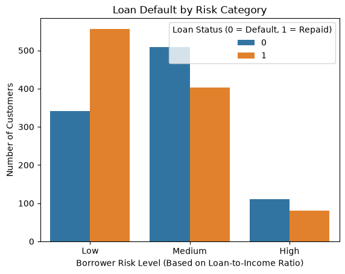

```python
# RISK SEGMENTATION (ADVANCED)
df["Risk_Level"] = pd.cut(
    df["Loan_Income_Ratio"],
    bins=[0, 0.02, 0.05, 1],
    labels=["Low", "Medium", "High"]
)

sns.countplot(x="Risk_Level", hue="Loan_Status", data=df)

plt.title("Loan Default by Risk Category")
plt.xlabel("Borrower Risk Level (Based on Loan-to-Income Ratio)")
plt.ylabel("Number of Customers")

plt.legend(title="Loan Status (0 = Default, 1 = Repaid)")

# plt.savefig("../images/14_risk_segmentation.png")
plt.show()
```

# Key Insights

These findings can support more effective lending and risk-management decisions.

# Business Recommendations

Based on the analysis, the following recommendations are proposed:

1. Strengthen credit-history screening during loan approval.
2. Monitor borrowers with high loan-to-income ratios more closely.
3. Develop risk-based lending policies.
4. Introduce early-warning systems for high-risk borrowers.
5. Provide financial education programs to reduce default likelihood.
6. Use predictive analytics to support credit-risk assessment.

These actions can improve portfolio quality and reduce default-related losses.

# Conclusion

This project explored loan default risk using data cleaning, feature engineering, and exploratory data analysis techniques.

Future work could include predictive modeling techniques such as Logistic Regression, Random Forest, or XGBoost to build a loan default prediction system.

# Skills Demonstrated

- Python
- Pandas
- NumPy
- Data Cleaning
- Feature Engineering
- Exploratory Data Analysis (EDA)
- Data Visualization
- Risk Analytics
- Business Intelligence